# Lecture 5: Exercises with answers

October 11th, 2018

```r
library(tidyverse)
```

# Exercise 1: Data Manipulation

## Part 1: The map functions from `purrr`

1. Use `purrr` functions to find the column means for `mtcars` dataset. Note that the mean performance cars in this dataset is very poor. That’s because these models are from the 70s!

```r
map_dbl(mtcars, mean)
```

```
       mpg        cyl       disp         hp       drat         wt       qsec         vs
 20.090625   6.187500 230.721875 146.687500   3.596563   3.217250  17.848750   0.437500
        am       gear       carb
  0.406250   3.687500   2.812500
```

2. Use `purrr` functions to generate 10 random normals for each of the mean parameter: $\mu = -18, 5, 10, 30$.

```r
map(c(-18, 5, 10, 30), rnorm, n = 10)
```

```
[[1]]
 [1] -17.78524 -16.55645 -18.26683 -18.79300 -17.29632 -17.69400 -17.58523 -17.43293 -17.88630
[10] -17.69365

[[2]]
 [1] 5.347321 4.934809 5.548192 5.193049 5.751195 5.290268 5.611618 5.105119 4.130849 5.374059

[[3]]
 [1] 10.151482 10.451136  9.458655  8.107506  8.941015  8.356018 11.618153  9.244071 10.464021
[10] 10.694236

[[4]]
 [1] 30.53905 29.84445 30.49597 30.19854 30.55803 29.53796 29.72368 30.15723 30.19064 31.25144
```

Below, `map` takes in each argument from a vector: 1, 2, 3, 4, 5 as the first argument `n =` for `rnorm()`. So the function will generate iteratively: one, two, three, four, five random normal numbers (with default mean 0, and standard deviaton 1).

```r
map(1:5, rnorm)
```

```
[[1]]
[1] 1.462465

[[2]]
[1] -0.6527792  0.8879679

[[3]]
[1] -0.5444105  0.0632058  1.0815356

[[4]]
[1] -0.806824010 -1.010737956 -0.009752065  0.854512944

[[5]]
[1]  0.3726064  1.9973607 -0.8488328 -3.6054650 -0.6221325
```

Below, note that `list(1:5)` is a list of one argument. This first argument is equal to a vector `c(1,2,3,4,5)`, and is supplied to `rnorm()` as the first argument, so map only loops over once and is equivalent to calling: `rnorm(c(1,2,3,4,5))`.

```r
map(list(1:5), rnorm)
```

```
[[1]]
[1] -1.7759034 -0.6146451  0.9189477 -0.2765776  0.2663184
```

The syntax below will be equivalent to the first example, since now `list(1, 2, 3, 4, 5)` is a list of 5 elements.

```r
map(list(1, 2, 3, 4, 5), rnorm)
```

```
[[1]]
[1] -0.7944809

[[2]]
[1] -0.1315415 -1.2634032

[[3]]
[1]  1.5606618  0.7713062 -0.9020260

[[4]]
[1]  0.03039048 -0.08102253  1.75360788  0.09264840

[[5]]
[1]  0.05674555 -0.09193836  1.08211983  1.03198044 -0.15894598
```

The example below is slightly different. Here, since we already force the `n` parameter to equal 7, the `map` function will loop over the vector `1:5` and supply each of the five elements to `rnorm()` as the second argument, `mean =`. Thus, resulting in a list of random normals, each of length 7, and each with different mean parameter.

```r
map(1:5, rnorm, n = 7)
```

```
[[1]]
[1] -1.421559  3.020436  2.522969  1.145590  2.748885  2.255065  2.059121

[[2]]
[1] 2.0947980 0.6159348 2.8849443 1.7046504 2.8177559 2.2685519 2.0247241

[[3]]
[1] 2.8449658 0.8793522 3.7138802 3.0804145 2.1913417 1.6089892 4.0487371

[[4]]
[1] 4.508546 2.549280 3.450783 1.892347 4.553530 5.839974 3.643115

[[5]]
[1] 6.356491 3.387126 4.927373 5.783132 3.527195 5.768116 6.608447
```

4. For looping over multiple arguments you can use `map2()` or `pmap()` function. Use `map2()` to generate 5 random numbers with for each pair of mean, and standard devtaion equal to: `c(2, 1), c(-3, 10), c(20, 0.1), c(-17, 2)`.

```r
map2(c(2, -3, 20, -17), c(1, 10, 0.1, 2), rnorm, n = 5)
```

```
[[1]]
[1] 3.067239 1.404513 2.196087 1.288083 1.733157

[[2]]
[1]  -4.456090  10.412209 -12.226832   2.456546  -2.986099

[[3]]
[1] 20.01114 19.94881 20.10059 20.07071 20.02437

[[4]]
[1] -18.82866 -16.32296 -19.45219 -16.60052 -19.49993
```

## Part 2: Merging

1. Identify the keys in the following datasets (you might need to install some packages and read some documentation):
- `Lahman::Batting`
- `nasaweather::atmos`
- `ggplot2::diamonds`

```r
Lahman::Batting %>%
    count(playerID, yearID, teamID, lgID, stint) %>%
    filter(n > 1)
```

```
# A tibble: 0 x 6
# ... with 6 variables: playerID <chr>, yearID <int>, teamID <fct>, lgID <fct>, stint <int>,
#   n <int>
```

```r
nasaweather::atmos %>%
    count(lat, long, year, month) %>%
    filter(n > 1)
```

```
# A tibble: 0 x 5
# ... with 5 variables: lat <dbl>, long <dbl>, year <int>, month <int>, n <int>
```

None of the combination of the variables uniquely identifies observations. Thus, the `row number` is the key for the `diamonds` dataset.

```r
ggplot2::diamonds %>%
    count(carat, cut, color, clarity, depth, table, price, x, y, z)  %>%
    filter(n > 1)
```

```
# A tibble: 143 x 11
   carat cut       color clarity depth table price     x     y     z     n
   <dbl> <ord>     <ord> <ord>   <dbl> <dbl> <int> <dbl> <dbl> <dbl> <int>
 1  0.3  Good      J     VS1      63.4    57   394  4.23  4.26  2.69     2
 2  0.3  Very Good G     VS2      63      55   526  4.29  4.31  2.71     2
 3  0.3  Very Good J     VS1      63.4    57   506  4.26  4.23  2.69     2
 4  0.3  Premium   D     SI1      62.2    58   709  4.31  4.28  2.67     2
 5  0.3  Ideal     G     VS2      63      55   675  4.31  4.29  2.71     2
 6  0.3  Ideal     G     IF       62.1    55   863  4.32  4.35  2.69     2
 7  0.3  Ideal     H     SI1      62.2    57   450  4.26  4.29  2.66     2
 8  0.3  Ideal     H     SI1      62.2    57   450  4.27  4.28  2.66     2
 9  0.31 Good      D     SI1      63.5    56   571  4.29  4.31  2.73     2
10  0.31 Very Good D     SI1      63.5    56   732  4.31  4.29  2.73     2
# ... with 133 more rows
```

2. Add the location (i.e. the lat and lon) of the destination airport  
   to `flights` dataset from `nycflights13` package. Then, construct a new data table `mean_delay` containing information on the average arrival delay for each destination airport and its location (i.e. the lat and lon). Remember that some of the recoreds are missing, so use `na.rm = TRUE` when computing means.

```r
library(nycflights13)
flights2 <- flights %>%
    left_join(airports, by = c("dest" = "faa"))
mean_delay <- flights2 %>%
    group_by(lat, lon, origin) %>%
    summarise(mean_dep_delay = mean(arr_delay, na.rm = TRUE))
```

You can plot your data on the map as follows:

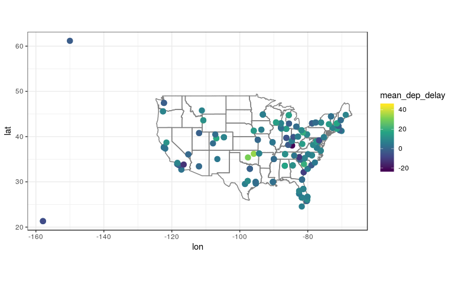

```r
(plt <- ggplot(mean_delay, aes(lon, lat)) +
    borders("state") +
    geom_point(aes(color = mean_dep_delay), size = 3) +
    coord_quickmap() + theme_bw() +
    scale_color_viridis_c())
```

## Part 3: Export datasets

1. Export the `mean_delay` data as a ‘.tsv’ file. Save it on your “Desktop” then check the file was properly saved, then delete it.

```r
write_tsv(mean_delay, path = "~/Desktop/mean_delay.tsv")
```

2. Check what objects are currently stored in your environment using `ls()`. Save `mean_delay` as a R object using `saveRDS()` function to save it as am ‘.rds’ file. Then, select 2 different objects from the environment and use `save()` to save them to an ‘.rda’ file. Then, remove these objects and the `mean_delay` tibble. Check that you can reload these objects from files you saved.

```r
ls()
```

```
 [1] "barplot"          "bayarea_counties" "bay_area_home"    "cities"
 [5] "custom_colors"    "dat"              "dbl.helix"        "df"
 [9] "df1"              "df2"              "flights2"         "home_per_sqft"
[13] "mean_delay"       "N"                "p"                "p3"
[17] "p5"               "phi"              "plt"              "pointsToLabel"
[21] "price_per_sqft"   "region_labels"    "regions"          "stocks"
[25] "theta"            "top10_States"     "treatment"        "url"
[29] "value_per_sqft"   "x"                "y"                "z"
[33] "zillow_url1"      "zillow_url2"
```

Saving as R objects:

```r
saveRDS(mean_delay, file = "~/Desktop/mean_delay.rds")
save(list = c("plt", "flights2"), file = "~/Desktop/two_objects.rda")
```

Now, you can delete the objects:

```r
rm(mean_delay, flights2, plt)
ls()
```

```
 [1] "barplot"          "bayarea_counties" "bay_area_home"    "cities"
 [5] "custom_colors"    "dat"              "dbl.helix"        "df"
 [9] "df1"              "df2"              "home_per_sqft"    "N"
[13] "p"                "p3"               "p5"               "phi"
[17] "pointsToLabel"    "price_per_sqft"   "region_labels"    "regions"
[21] "stocks"           "theta"            "top10_States"     "treatment"
[25] "url"              "value_per_sqft"   "x"                "y"
[29] "z"                "zillow_url1"      "zillow_url2"
```

And then load them in using the following:

```r
mean_delay <- readRDS("~/Desktop/mean_delay.rds")
mean_delay
```

| lat | lon | origin | mean_dep_delay |
| --- | --- | --- | --- |
| 21.31868 | -157.92243 | EWR | 3.92200557 |
| 21.31868 | -157.92243 | JFK | -6.91520468 |
| 24.55611 | -81.75956 | LGA | 6.35294118 |
| 25.79325 | -80.29056 | EWR | 3.97927859 |
| 25.79325 | -80.29056 | JFK | -1.98721461 |
| 25.79325 | -80.29056 | LGA | -0.06576640 |
| 26.07258 | -80.15275 | EWR | 7.76122995 |
| 26.07258 | -80.15275 | JFK | 6.93254157 |
| 26.07258 | -80.15275 | LGA | 9.61236382 |
| 26.53617 | -81.75517 | EWR | -2.25912921 |

[output cut: 209 more lines]

```r
load("~/Desktop/two_objects.rda")
ls()
```

```
 [1] "barplot"          "bayarea_counties" "bay_area_home"    "cities"
 [5] "custom_colors"    "dat"              "dbl.helix"        "df"
 [9] "df1"              "df2"              "flights2"         "home_per_sqft"
[13] "mean_delay"       "N"                "p"                "p3"
[17] "p5"               "phi"              "plt"              "pointsToLabel"
[21] "price_per_sqft"   "region_labels"    "regions"          "stocks"
[25] "theta"            "top10_States"     "treatment"        "url"
[29] "value_per_sqft"   "x"                "y"                "z"
[33] "zillow_url1"      "zillow_url2"
```

# Exercise 2: Exploratory Data Analysis

Zillow provides data on home prices, including median rental price per square feet and the median estimated home value. There are many more statistics provided by zillow in [this website](https://www.zillow.com/research/data/) that you can explore.

```r
zillow_url1 <- paste0("http://files.zillowstatic.com/research/public/City/",
                    "City_MedianRentalPricePerSqft_AllHomes.csv")
zillow_url2 <- paste0("http://files.zillowstatic.com/research/public/City/",
                      "City_ZriPerSqft_AllHomes.csv")
price_per_sqft <- read_csv(zillow_url1)
value_per_sqft <- read_csv(zillow_url2)
```

```r
# First, we tidy the datasets:
price_per_sqft <- price_per_sqft %>%
    select(-Metro) %>%
    gather(`2010-01`:`2018-08`, key = "date", value = "price")
value_per_sqft <- value_per_sqft %>%
    select(RegionID:CountyName, `2011-01`:`2018-08`) %>%
    gather(`2011-01`:`2018-08`, key = "date", value = "value")
# Do the inner join:
home_per_sqft <- price_per_sqft %>%
    inner_join(value_per_sqft)
# Format dates:
home_per_sqft <- home_per_sqft %>%
    mutate(date = paste0(date, "-01"),
           date = as.Date(date))
# We filter to only top 10 priciest states this year
# excluding DC and HI:
top10_States <- home_per_sqft %>%
    filter(date >= as.Date("2018-01-01")) %>%
    filter(State != "HI", State != "DC") %>%
    group_by(State) %>%
    summarise(price = mean(price, na.rm = TRUE)) %>%
    top_n(10)
home_per_sqft <- home_per_sqft %>%
    filter(State %in% top10_States$State)
#rm(price_per_sqft, value_per_sqft)
```

The most expensive states by median home price per sq. ft. are:

```r
top10_States
```

```
# A tibble: 10 x 2
   State price
   <chr> <dbl>
 1 CA     1.91
 2 CO     1.37
 3 CT     1.41
 4 MA     2.08
 5 MD     1.33
 6 ME     1.81
 7 NH     1.61
 8 NJ     1.58
 9 NY     1.95
10 RI     1.64
```

1. For the current year (2018), using the filtered `home_per_sqft` dataset show the relationship between the value and the price per square foot of homes in 10 chosen states. The value is a dollar-denominated and estimated by Zillow.
- Is there a correlation between the price and the value per square foot?
- Are there any atypical trends you observe?
- Are there any clusters of regions that are pricier than, expected based on their estimated value? Find, the `RegionName` for an example these outliers, and see if it makes sense.
- Are there any clusters of regions that have higher value than, expected based on how cheap they are? Find, the `RegionName` for an example of these outliers, and see if it makes sense.

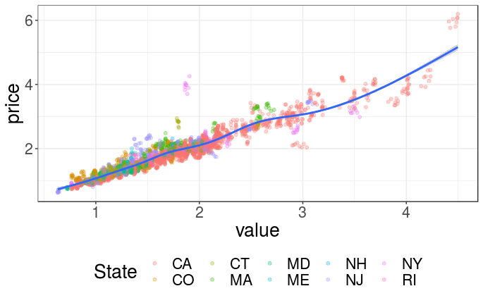

```r
home_per_sqft %>%
    filter(date >= as.Date("2018-01-01")) %>%
    ggplot(aes(x = value, y = price)) +
    geom_point(aes(color = State), alpha = 0.3) +
    theme(legend.position = "bottom") +
    geom_smooth()
```

```r
home_per_sqft %>%
    filter(date >= as.Date("2018-01-01")) %>%
    filter(price > 5, value > 4)
```

```
# A tibble: 8 x 9
  RegionName State CountyName  SizeRank date       price RegionID Metro                   value
  <chr>      <chr> <chr>          <int> <date>     <dbl>    <int> <chr>                   <dbl>
1 Malibu     CA    Los Angeles     1435 2018-01-01  5.94    12520 Los Angeles-Long Beach…  4.49
2 Malibu     CA    Los Angeles     1435 2018-02-01  6.07    12520 Los Angeles-Long Beach…  4.49
3 Malibu     CA    Los Angeles     1435 2018-03-01  6.19    12520 Los Angeles-Long Beach…  4.50
4 Malibu     CA    Los Angeles     1435 2018-04-01  6.07    12520 Los Angeles-Long Beach…  4.49
5 Malibu     CA    Los Angeles     1435 2018-05-01  5.80    12520 Los Angeles-Long Beach…  4.48
6 Malibu     CA    Los Angeles     1435 2018-06-01  6.04    12520 Los Angeles-Long Beach…  4.45
7 Malibu     CA    Los Angeles     1435 2018-07-01  5.76    12520 Los Angeles-Long Beach…  4.42
8 Malibu     CA    Los Angeles     1435 2018-08-01  5.96    12520 Los Angeles-Long Beach…  4.41
```

```r
home_per_sqft %>%
    filter(date >= as.Date("2018-01-01")) %>%
    filter(price > 3, value < 2)
```

```
# A tibble: 8 x 9
  RegionName State CountyName SizeRank date       price RegionID Metro                    value
  <chr>      <chr> <chr>         <int> <date>     <dbl>    <int> <chr>                    <dbl>
1 New York   NY    Queens            1 2018-01-01  4.26     6181 New York-Newark-Jersey …  1.90
2 New York   NY    Queens            1 2018-02-01  3.89     6181 New York-Newark-Jersey …  1.89
3 New York   NY    Queens            1 2018-03-01  3.71     6181 New York-Newark-Jersey …  1.88
4 New York   NY    Queens            1 2018-04-01  3.99     6181 New York-Newark-Jersey …  1.87
5 New York   NY    Queens            1 2018-05-01  4        6181 New York-Newark-Jersey …  1.87
6 New York   NY    Queens            1 2018-06-01  4.04     6181 New York-Newark-Jersey …  1.86
7 New York   NY    Queens            1 2018-07-01  3.94     6181 New York-Newark-Jersey …  1.86
8 New York   NY    Queens            1 2018-08-01  3.83     6181 New York-Newark-Jersey …  1.86
```

```r
home_per_sqft %>%
    filter(date >= as.Date("2018-01-01")) %>%
    filter(price < 2.2, value > 2.8)
```

```
# A tibble: 8 x 9
  RegionName State CountyName  SizeRank date       price RegionID Metro                   value
  <chr>      <chr> <chr>          <int> <date>     <dbl>    <int> <chr>                   <dbl>
1 San Marino CA    Los Angeles     1468 2018-01-01  2.04    54299 Los Angeles-Long Beach…  3.04
2 San Marino CA    Los Angeles     1468 2018-02-01  2.15    54299 Los Angeles-Long Beach…  3.01
3 San Marino CA    Los Angeles     1468 2018-03-01  2.04    54299 Los Angeles-Long Beach…  2.99
4 San Marino CA    Los Angeles     1468 2018-04-01  2.07    54299 Los Angeles-Long Beach…  2.97
5 San Marino CA    Los Angeles     1468 2018-05-01  2.19    54299 Los Angeles-Long Beach…  2.95
6 San Marino CA    Los Angeles     1468 2018-06-01  2.13    54299 Los Angeles-Long Beach…  2.93
7 San Marino CA    Los Angeles     1468 2018-07-01  2.12    54299 Los Angeles-Long Beach…  2.91
8 San Marino CA    Los Angeles     1468 2018-08-01  2.10    54299 Los Angeles-Long Beach…  2.90
```

2. Collapse the data by computing the average of the median home price per square foot for each (state, date) pair. Then show the price trend over time for each of the top 10 states.

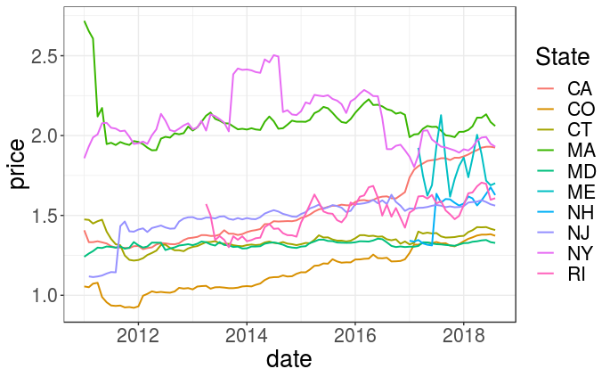

```r
df <- home_per_sqft %>%
    group_by(State, date) %>%
    summarise(
        price = mean(price, na.rm = TRUE),
        value = mean(value, na.rm = TRUE))
ggplot(data = df, aes(x = date, y = price, color = State)) +
    geom_line(lwd = 0.7)
```

3. Now, subset your `home_per_sqft` dataset to homes located in the Bay Area:

```r
bayarea_counties <- c("Alameda", "Napa", "Santa Clara", "Contra Costa",
                      "San Francisco", "Solano", "Marin", "San Mateo",
                      "Sonoma")
bay_area_home <- home_per_sqft %>%
    filter(CountyName %in% bayarea_counties)
```

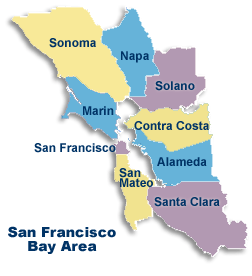

Filter your observations to the once after “2013-09-01”. Then generate a boxplot of home prices per square foot for the following regions:

```r
cities <- c("Oakland", "San Francisco", "Berkeley", "San Jose",
            "San Mateo", "Redwood City", "Mountain View", "Napa",
            "South San Francisco", "Menlo Park", "Cupertino")
```

For which region were the median home prices per square foot highest over the most recent 5 years period?

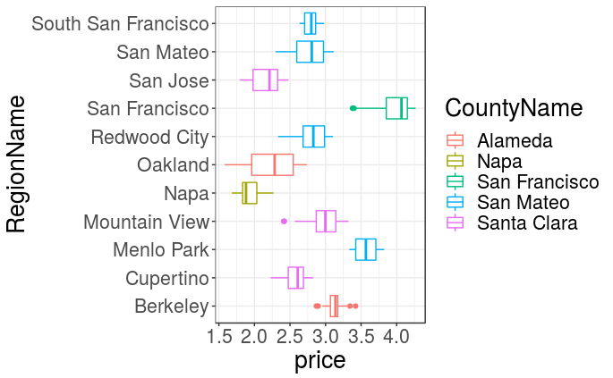

```r
df <- bay_area_home %>%
    filter(date >= as.Date("2013-09-01")) %>%
    filter(RegionName %in% cities)
ggplot(df, aes(x = RegionName, y = price)) +
    geom_boxplot(aes(color = CountyName)) +
    coord_flip()
```

4. For the same regions plot the prices over time.

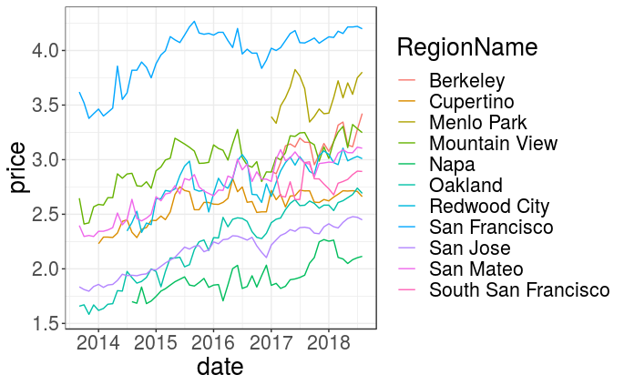

```r
ggplot(df) +
    geom_line(aes(date, price, color = RegionName))
```

If you are curious, you can repeat this type of analysis for the listing prices of home sales using the following files from zillow: ‘City_MedianListingPricePerSqft_AllHomes.csv’, ‘City_Zhvi_AllHomes.csv’.

# Exercise 3: Interactive graphics with `plotly`

First generate the following (x,y,z) coordinates for your scatter 3D plot:

```r
library(plotly)
theta <- 2 * pi * runif(1000)
phi <- pi * runif(1000)
x <- sin(phi) * cos(theta)
y <- sin(phi) * sin(theta)
z <- cos(phi)
dat <- data.frame(x, y, z)
```

1. Generate a scatter plot with (x, y, z) coordinates, just computed. What do you observe?

```r
plot_ly(dat, x = ~x, y = ~y, z = ~z,
        type = "scatter3d", mode = "markers", marker = list(size = 3))
```

2. Now generate new points as follows.

```r
N <- 10
theta <- rep(2*pi * seq(0, 1, length.out = 100), N)
phi <- rep(pi * seq(0, 1, length.out = N*100))
x <- sin(phi) * cos(theta)
y <- sin(phi) * sin(theta)
z <- cos(phi)
dat <- data.frame(x, y, z)
```

Then, use `plotly` to create a 3D scatter point plot and a separate line plot. Color the points by their ordering in the data-frame.

```r
plot_ly(dat, x = ~x, y = ~y, z = ~z, color = 1:1000) %>%
  add_markers(marker = list(size = 2))
```

```r
plot_ly(dat, x = ~x, y = ~y, z = ~z, color = 1:1000, type = "scatter3d",
        mode = "lines", line = list(width = 3))
```